# Central Limit Theorem

Institut für Organisation und Globale Managementstudien, JKU Linz

## The Problem

Suppose we have measurements from a randomly drawn sample representing the number of defects per 10,000 units.

```
3  1  4  6  1  1  3  6  1   3
```

What can we infer about the population?

## The Answer

We can infer the **population mean** within a defined (un)certainty.

"The 95% confidence interval for the mean defects per 10,000 unitsis 1.49 to 4.31."

## Fair Die Rolls

Probability Mass Function (PMF) of a fair die.

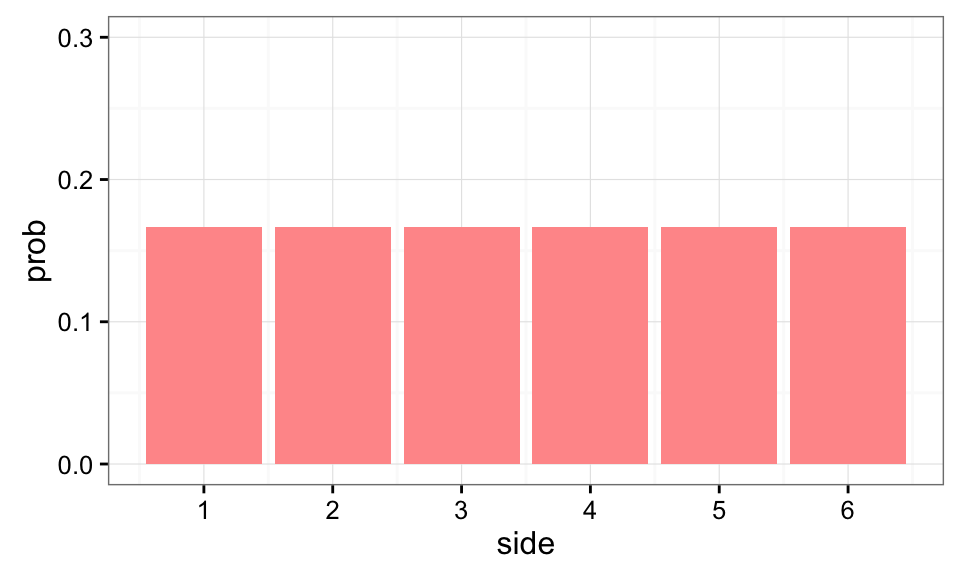

## Expected Value

- The **expected value** or **mean** of a random variable is the center of its distribution
- For discrete random variable \(X\) with PMF \(p(x)\), it is defined as follows\[ E[X] = \sum_x xp(x). \]where the sum is taken over the possible values of \(x\)
- \(E[X]\) represents the center of mass of a collection of locations and weights, \(\{x, p(x)\}\)

## Expected Value for Fair Die Rolls

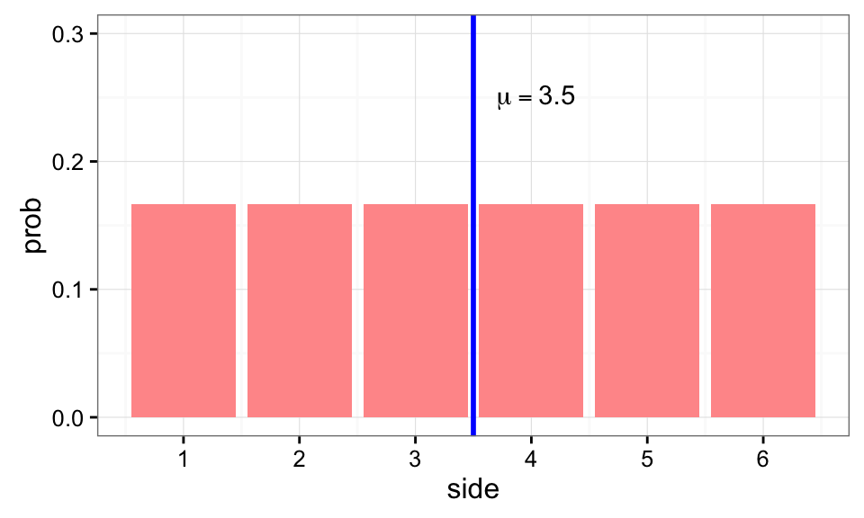

\(E[X] = 1 \times \frac{1}{6} + 2 \times \frac{1}{6}+ 3 \times \frac{1}{6} + 4 \times \frac{1}{6} + 5 \times \frac{1}{6} + 6 \times \frac{1}{6} = 3.5\)

## Variance

- The variance of a random variable is a measure of *spread*
- If \(X\) is a random variable with mean \(\mu\), the variance of \(X\) is defined as

\[ \begin{align*} Var(X) &= E[(X - \mu)^2]\\ &= E[X^2] - E[X]^2 \end{align*} \]

- The variance is the expected (squared) distance from the mean
- Densities with a higher variance are more spread out than densities with a lower variance

## Standard Deviation

- The square root of the variance is called the **standard deviation**
- The standard deviation has the same units as \(X\)

\[ \begin{align*} \sigma &= \sqrt{Var(X)}\\ &= \sqrt{E[X^2] - E[X]^2} \end{align*} \]

## Standard Deviation for Fair Die Rolls

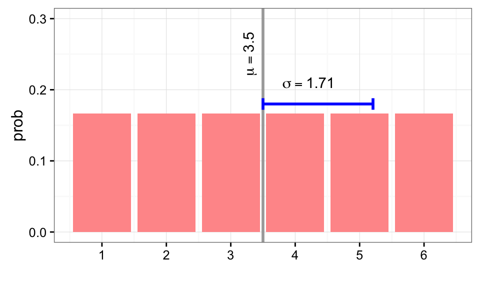

\(SD(X) = \sqrt{2.92} \approx 1.71\)

## Unfair Die Rolls

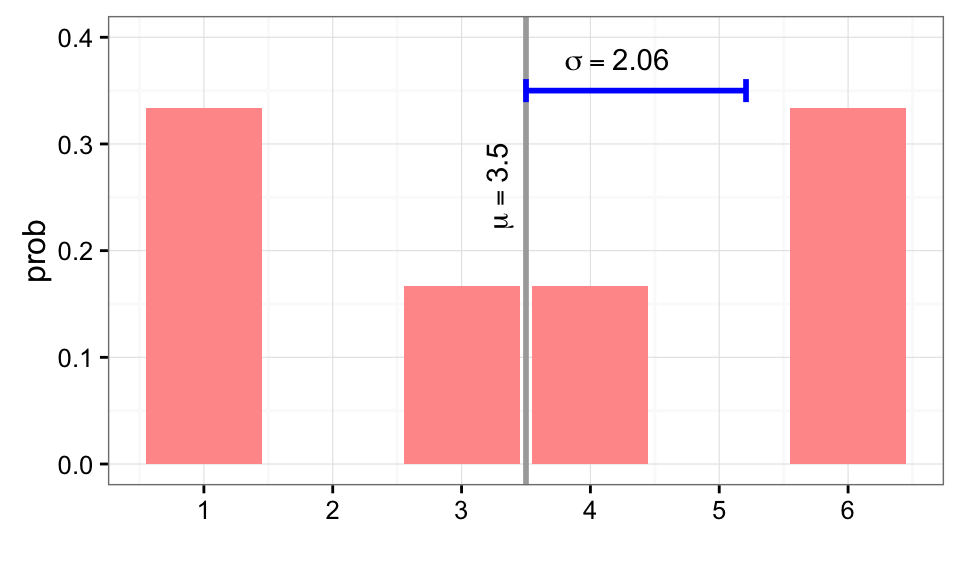

\(E[X] = \mu = 1 \times \frac{2}{6} + 2 \times 0 + 3 \times \frac{1}{6} + 4 \times \frac{1}{6} + 5 \times 0 + 6 \times \frac{2}{6} = 3.5\)

\(E[X^2] = 1 ^ 2 \times \frac{2}{6} + 3 ^ 2 \times \frac{1}{6} + 4 ^ 2 \times \frac{1}{6} + 6 ^ 2 \times \frac{2}{6} = 16.5\)

\(Var(X) = \sigma ^ 2 = E[X^2] - E[X] ^ 2 = 4.25\)

\(SD(X) = \sqrt{4.25} \approx 2.06\)

## Samples of n = 10

Let's roll this unfair die ten times and write down the numbers.

```
 X1 X2 X3 X4 X5 X6 X7 X8 X9 X10
  3  1  4  6  1  1  3  6  1   3
```

Let's do this a few more times (e.g. 1,000 times):

```
 X1 X2 X3 X4 X5 X6 X7 X8 X9 X10
  4  4  6  4  6  1  1  1  3   4
  3  1  6  1  4  3  1  1  6   1
  4  6  4  3  6  1  6  1  6   1
  6  3  1  3  1  6  6  1  6   4
  1  1  4  3  3  3  4  3  1   1
  1  1  1  4  4  1  6  4  1   1
  6  3  6  1  6  3  4  6  4   4
  3  4  6  1  4  1  4  4  1   3
  4  4  4  3  4  6  1  6  3   1
```

## Sample Means n = 10

Next, calculate the sample means.

```
   X1 X2 X3 X4 X5 X6 X7 X8 X9 X10 mean
1   3  1  4  6  1  1  3  6  1   3  2.9
2   4  4  6  4  6  1  1  1  3   4  3.4
3   3  1  6  1  4  3  1  1  6   1  2.7
4   4  6  4  3  6  1  6  1  6   1  3.8
5   6  3  1  3  1  6  6  1  6   4  3.7
6   1  1  4  3  3  3  4  3  1   1  2.4
7   1  1  1  4  4  1  6  4  1   1  2.4
8   6  3  6  1  6  3  4  6  4   4  4.3
9   3  4  6  1  4  1  4  4  1   3  3.1
10  4  4  4  3  4  6  1  6  3   1  3.6
```

## Distribution of Sample Means

### n = 10; rep = 1000

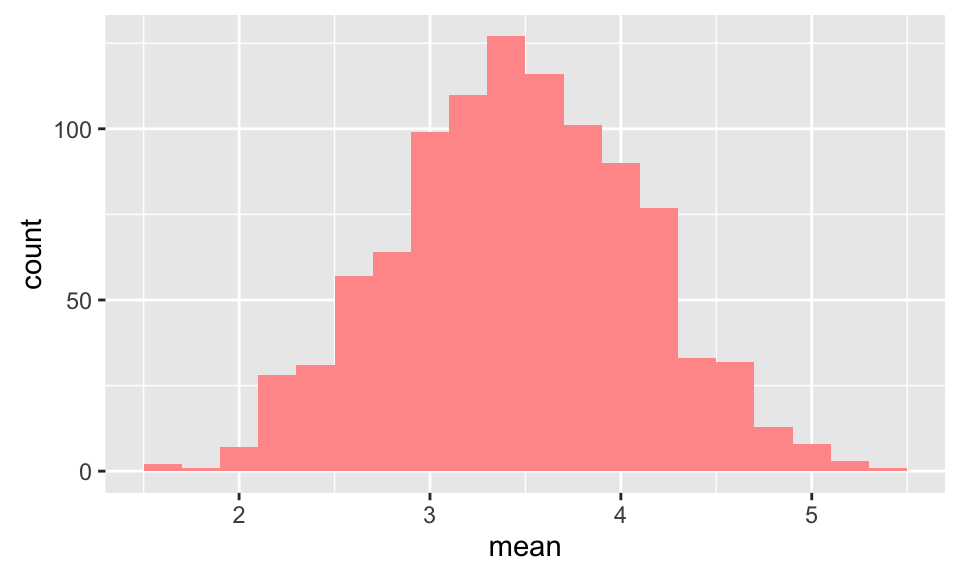

## Monte Carlo Simulation

## Simulation of Sample Means

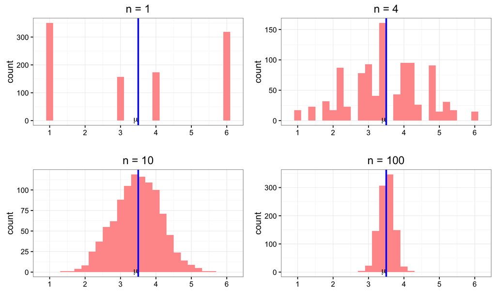

## Observations

- The sample means are distributed around the population mean
- The variance deceases as n gets greater
- The distribution looks like a bell curve

## CLT Formal

Lindeberg–Lévy CLT:

Suppose \(\{X_1, X_2, ...\}\) is a sequence of i.i.d. random variables with \(E[Xi_] = \mu\) and \(Var[X_i] = \sigma^2 < \infty\).

Then as \(n\) approaches infinity, the random variables \(\sqrt{n}(S_n − \mu)\) converge in distribution to a normal \(N(0, \sigma^2)\)

\[ \sqrt{n} \left( \left(\frac{1}{n}\sum_{i=1}^{n} X_i \right) - \mu\right) \overset{d}{\to} N(0, \sigma^2) \]

## Practical Application

Estimate of the confidence interval the mean:

\[ \bar{x} \pm z_{\alpha/2} \frac{s}{\sqrt{n}} \]

Suppose the significance level \(\alpha = 0.05\):

In 95% of random samples of size \(n\) the actual population mean lays withinthe boundaries of the confidence interval.

For small samples we need to use the t distribution:

\[ \bar{x} \pm t_{\alpha/2,\ n-1} \frac{s}{\sqrt{n}} \]

## Example from the Beginning

Suppose we have have measurements from a randomly drawn sample:

```
3  1  4  6  1  1  3  6  1   3
```

```r
x <- c(3, 1, 4, 6, 1, 1, 3, 6, 1, 3)
mean(x)
```

```
## [1] 2.9
```

```r
mean(x) + c(-1, 1) * qt(.975, 9) * sd(x)/sqrt(10)
```

```
## [1] 1.491314 4.308686
```

## Simulation

```
## [1] 0.942
```

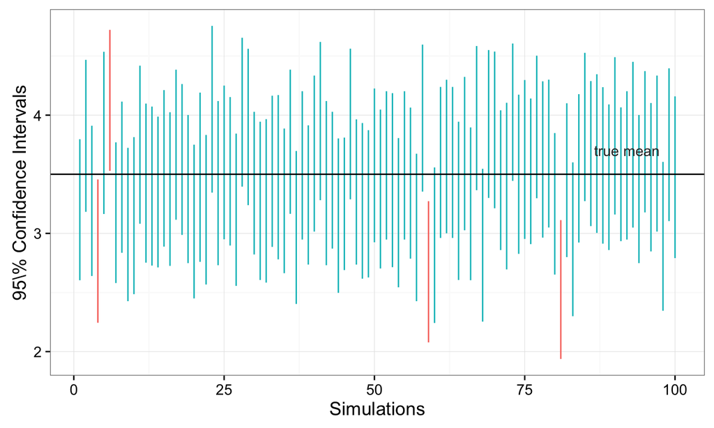

## Interpretation

The 95% refers to the fact that if one were to repeatedly get samples of size n, about 95% of the intervals obtained would contain \(\mu\).

## Example

```r
ssl  <- iris[iris$Species == "setosa", 1]

mn  <- mean(ssl)
s  <- sd(ssl)
n  <- length(ssl)

error  <- qt(.975, n-1) * s / sqrt(n)
SEM  <- mn + c(-1, 1) * error
```

The 95% confidence interval for the mean sepal length of *iris setosa* is 5.01 ± 0.1 cm.

## Alternative Computation

```r
t.test(ssl, conf.level = 0.95)
```

```
##
##  One Sample t-test
##
## data:  ssl
## t = 100.42, df = 49, p-value < 2.2e-16
## alternative hypothesis: true mean is not equal to 0
## 95 percent confidence interval:
##  4.905824 5.106176
## sample estimates:
## mean of x
##     5.006
```

## Nomenclature

Greek letters refer to population statistics, Latin letters to sample statistics.

- Suppose \(X_i\) are iid with mean \(\mu\) and variance \(\sigma^2\)
- \(S^2\) estimates \(\sigma^2\)
- \(S / \sqrt{n}\) estimates \(\sigma / \sqrt{n}\) the standard error of the mean
- \(S / \sqrt{n}\) is called the sample standard error (of the mean)

## Acknowledgements

This class and many slides were inspired by:

**Brian Caffo, Jeff Leek, and Roger Peng**  
Department of Biostatistics  
Johns Hopkins Bloomberg School of Public Health

and the

[Coursera Data Science Specialization Program](https://www.coursera.org/specialization/jhudatascience/1?utm_medium=courseDescripTop)